# W3cubDocs

#### Methods

| `aic`(X) | Akaike information criterion for the current model on the input X. |
| --- | --- |
| `bic`(X) | Bayesian information criterion for the current model on the input X. |
| `fit`(X[, y]) | Estimate model parameters with the EM algorithm. |
| `fit_predict`(X[, y]) | Estimate model parameters using X and predict the labels for X. |
| `get_params`([deep]) | Get parameters for this estimator. |
| `predict`(X) | Predict the labels for the data samples in X using trained model. |
| `predict_proba`(X) | Predict posterior probability of each component given the data. |
| `sample`([n_samples]) | Generate random samples from the fitted Gaussian distribution. |
| `score`(X[, y]) | Compute the per-sample average log-likelihood of the given data X. |
| `score_samples`(X) | Compute the weighted log probabilities for each sample. |
| `set_params`(**params) | Set the parameters of this estimator. |

**`__init__(n_components=1, covariance_type=’full’, tol=0.001, reg_covar=1e-06, max_iter=100, n_init=1, init_params=’kmeans’, weights_init=None, means_init=None, precisions_init=None, random_state=None, warm_start=False, verbose=0, verbose_interval=10)` [[source]](https://github.com/scikit-learn/scikit-learn/blob/bac89c2/sklearn/mixture/gaussian_mixture.py#L589)**

**`aic(X)` [[source]](https://github.com/scikit-learn/scikit-learn/blob/bac89c2/sklearn/mixture/gaussian_mixture.py#L744)**

Akaike information criterion for the current model on the input X.

| Parameters: | **`X : array of shape (n_samples, n_dimensions)`** |
| --- | --- |
| Returns: | **`aic : float`** The lower the better. |

**`bic(X)` [[source]](https://github.com/scikit-learn/scikit-learn/blob/bac89c2/sklearn/mixture/gaussian_mixture.py#L729)**

Bayesian information criterion for the current model on the input X.

| Parameters: | **`X : array of shape (n_samples, n_dimensions)`** |
| --- | --- |
| Returns: | **`bic : float`** The lower the better. |

**`fit(X, y=None)` [[source]](https://github.com/scikit-learn/scikit-learn/blob/bac89c2/sklearn/mixture/base.py#L172)**

Estimate model parameters with the EM algorithm.

The method fits the model `n_init` times and sets the parameters with which the model has the largest likelihood or lower bound. Within each trial, the method iterates between E-step and M-step for `max_iter` times until the change of likelihood or lower bound is less than `tol`, otherwise, a `ConvergenceWarning` is raised. If `warm_start` is `True`, then `n_init` is ignored and a single initialization is performed upon the first call. Upon consecutive calls, training starts where it left off.

| Parameters: | **`X : array-like, shape (n_samples, n_features)`** List of n_features-dimensional data points. Each row corresponds to a single data point. |
| --- | --- |
| Returns: | **self** |

**`fit_predict(X, y=None)` [[source]](https://github.com/scikit-learn/scikit-learn/blob/bac89c2/sklearn/mixture/base.py#L197)**

Estimate model parameters using X and predict the labels for X.

The method fits the model n_init times and sets the parameters with which the model has the largest likelihood or lower bound. Within each trial, the method iterates between E-step and M-step for `max_iter` times until the change of likelihood or lower bound is less than `tol`, otherwise, a `ConvergenceWarning` is raised. After fitting, it predicts the most probable label for the input data points.

New in version 0.20.

| Parameters: | **`X : array-like, shape (n_samples, n_features)`** List of n_features-dimensional data points. Each row corresponds to a single data point. |
| --- | --- |
| Returns: | **`labels : array, shape (n_samples,)`** Component labels. |

**`get_params(deep=True)` [[source]](https://github.com/scikit-learn/scikit-learn/blob/bac89c2/sklearn/base.py#L166)**

Get parameters for this estimator.

| Parameters: | **`deep : boolean, optional`** If True, will return the parameters for this estimator and contained subobjects that are estimators. |
| --- | --- |
| Returns: | **`params : mapping of string to any`** Parameter names mapped to their values. |

**`predict(X)` [[source]](https://github.com/scikit-learn/scikit-learn/blob/bac89c2/sklearn/mixture/base.py#L356)**

Predict the labels for the data samples in X using trained model.

| Parameters: | **`X : array-like, shape (n_samples, n_features)`** List of n_features-dimensional data points. Each row corresponds to a single data point. |
| --- | --- |
| Returns: | **`labels : array, shape (n_samples,)`** Component labels. |

**`predict_proba(X)` [[source]](https://github.com/scikit-learn/scikit-learn/blob/bac89c2/sklearn/mixture/base.py#L374)**

Predict posterior probability of each component given the data.

| Parameters: | **`X : array-like, shape (n_samples, n_features)`** List of n_features-dimensional data points. Each row corresponds to a single data point. |
| --- | --- |
| Returns: | **`resp : array, shape (n_samples, n_components)`** Returns the probability each Gaussian (state) in the model given each sample. |

**`sample(n_samples=1)` [[source]](https://github.com/scikit-learn/scikit-learn/blob/bac89c2/sklearn/mixture/base.py#L394)**

Generate random samples from the fitted Gaussian distribution.

| Parameters: | **`n_samples : int, optional`** Number of samples to generate. Defaults to 1. |
| --- | --- |
| Returns: | **`X : array, shape (n_samples, n_features)`** Randomly generated sample **`y : array, shape (nsamples,)`** Component labels |

**`score(X, y=None)` [[source]](https://github.com/scikit-learn/scikit-learn/blob/bac89c2/sklearn/mixture/base.py#L340)**

Compute the per-sample average log-likelihood of the given data X.

| Parameters: | **`X : array-like, shape (n_samples, n_dimensions)`** List of n_features-dimensional data points. Each row corresponds to a single data point. |
| --- | --- |
| Returns: | **`log_likelihood : float`** Log likelihood of the Gaussian mixture given X. |

**`score_samples(X)` [[source]](https://github.com/scikit-learn/scikit-learn/blob/bac89c2/sklearn/mixture/base.py#L321)**

Compute the weighted log probabilities for each sample.

| Parameters: | **`X : array-like, shape (n_samples, n_features)`** List of n_features-dimensional data points. Each row corresponds to a single data point. |
| --- | --- |
| Returns: | **`log_prob : array, shape (n_samples,)`** Log probabilities of each data point in X. |

**`set_params(**params)` [[source]](https://github.com/scikit-learn/scikit-learn/blob/bac89c2/sklearn/base.py#L189)**

Set the parameters of this estimator.

The method works on simple estimators as well as on nested objects (such as pipelines). The latter have parameters of the form `<component>__<parameter>` so that it’s possible to update each component of a nested object.

| Returns: | **self** |
| --- | --- |

## Examples using `sklearn.mixture.GaussianMixture`

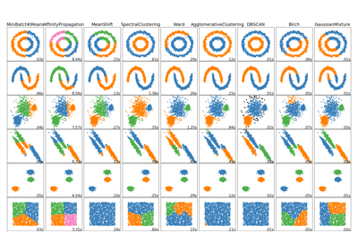

Comparing different clustering algorithms on toy datasets

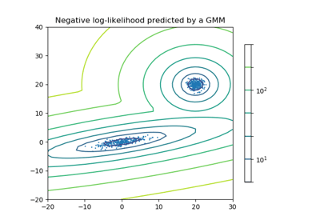

Density Estimation for a Gaussian mixture

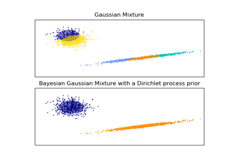

Gaussian Mixture Model Ellipsoids

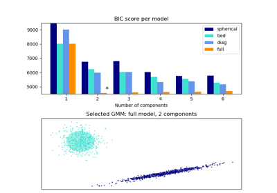

Gaussian Mixture Model Selection

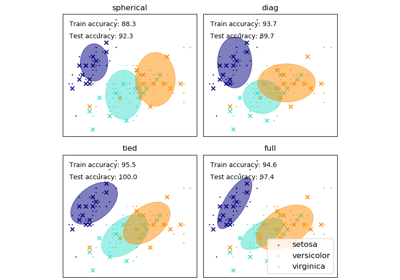

GMM covariances

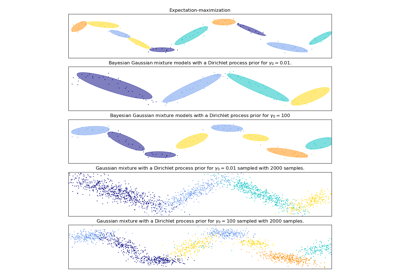

Gaussian Mixture Model Sine Curve